# rs_pilot_rq1_tests

Author

Risk Rejection Team: Guannan Shen

Published

October 28, 2024

# Research Question 1

**The question: Does asking about people’s perceived risk of developing breast cancer prior to providing their risk estimate affect the likelihood of them expressing risk skepticism?**

Conduct an experiment with 3 conditions, randomly assigned in a 1:1:1 allocation:

1. Risk perceptions measured before participants viewed the Gail model risk questions vs.
2. Risk perceptions measured after participants viewed the Gail model risk questions but before they viewed the results vs.
3. Risk perceptions measured after participants viewed their risk results.

Where **c** is the control group, and group **a, b, c** correspond to 1, 2, 3 in the Experimental condition variable.

## Demographics

**Table 1. Subjects Characteristics**

| **Characteristics** | **N** | **Overall** N = 527 <sup>1</sup> | **RReject_diff groups** **RReject_diff < 90** N = 500 <sup>1</sup> | **RReject_diff groups** **RReject_diff >= 90** N = 27 <sup>1</sup> | **p-value** <sup>2</sup> |  |
| --- | --- | --- | --- | --- | --- | --- |
| Age | 527 | 55.01 (9.90) | 55.18 (9.89) | 51.81 (9.74) |  | 0.091 |
| Race/Ethnicity | 527 |  |  |  | 0.2 |  |
| 1 |  | 238 (45%) | 230 (46%) | 8 (30%) |  |  |
| 2 |  | 185 (35%) | 175 (35%) | 10 (37%) |  |  |
| 3 |  | 26 (4.9%) | 23 (4.6%) | 3 (11%) |  |  |
| 4 |  | 57 (11%) | 53 (11%) | 4 (15%) |  |  |
| 5 |  | 21 (4.0%) | 19 (3.8%) | 2 (7.4%) |  |  |
| PlaceofBirth | 26 |  |  |  | >0.9 |  |
| 1 |  | 6 (23%) | 5 (22%) | 1 (33%) |  |  |
| 2 |  | 20 (77%) | 18 (78%) | 2 (67%) |  |  |
| (Missing) |  | 501 | 477 | 24 |  |  |
| Asian/AA | 57 |  |  |  | 0.8 |  |
| 6 |  | 13 (23%) | 13 (25%) | 0 (0%) |  |  |
| 7 |  | 6 (11%) | 6 (11%) | 0 (0%) |  |  |
| 8 |  | 10 (18%) | 9 (17%) | 1 (25%) |  |  |
| 11 |  | 28 (49%) | 25 (47%) | 3 (75%) |  |  |
| (Missing) |  | 470 | 447 | 23 |  |  |
| FirstMenses | 527 |  |  |  | 0.009 |  |
| 7 |  | 152 (29%) | 145 (29%) | 7 (26%) |  |  |
| 12 |  | 266 (50%) | 258 (52%) | 8 (30%) |  |  |
| 14 |  | 109 (21%) | 97 (19%) | 12 (44%) |  |  |
| FirstChild | 527 |  |  |  | 0.6 |  |
| 19 |  | 97 (18%) | 95 (19%) | 2 (7.4%) |  |  |
| 20 |  | 126 (24%) | 118 (24%) | 8 (30%) |  |  |
| 25 |  | 85 (16%) | 81 (16%) | 4 (15%) |  |  |
| 30 |  | 88 (17%) | 84 (17%) | 4 (15%) |  |  |
| 98 |  | 129 (24%) | 120 (24%) | 9 (33%) |  |  |
| 99 |  | 2 (0.4%) | 2 (0.4%) | 0 (0%) |  |  |
| family_history | 527 |  |  |  | 0.071 |  |
| 0 |  | 372 (71%) | 357 (71%) | 15 (56%) |  |  |
| 1 |  | 93 (18%) | 86 (17%) | 7 (26%) |  |  |
| 2 |  | 41 (7.8%) | 36 (7.2%) | 5 (19%) |  |  |
| 99 |  | 21 (4.0%) | 21 (4.2%) | 0 (0%) |  |  |
| biopsy | 527 |  |  |  | 0.7 |  |
| 0 |  | 434 (82%) | 413 (83%) | 21 (78%) |  |  |
| 1 |  | 83 (16%) | 77 (15%) | 6 (22%) |  |  |
| 2 |  | 10 (1.9%) | 10 (2.0%) | 0 (0%) |  |  |
| num_biopsies | 83 |  |  |  | >0.9 |  |
| 1 |  | 66 (80%) | 61 (79%) | 5 (83%) |  |  |
| 2 |  | 17 (20%) | 16 (21%) | 1 (17%) |  |  |
| (Missing) |  | 444 | 423 | 21 |  |  |
| hyperplasia | 83 |  |  |  | 0.7 |  |
| 0 |  | 40 (48%) | 36 (47%) | 4 (67%) |  |  |
| 1 |  | 14 (17%) | 13 (17%) | 1 (17%) |  |  |
| 2 |  | 29 (35%) | 28 (36%) | 1 (17%) |  |  |
| (Missing) |  | 444 | 423 | 21 |  |  |

<sup>1</sup> Mean (SD); n (%)  
<sup>2</sup> One-way analysis of means (not assuming equal variances); Fisher’s exact test

## Questions Breakdown

Does experimental condition predict a) numeric absolute risk skepticism; (RReject_diff, which is RReject1 - abs_risk_rouned)

2. disbelief risk skepticism; (RReject_mean, mean of RReject4 - 7)
3. comparative risk skepticism; (Categorical outcome combine RReject3 and Abs_risk_relative_risk, use 3 levels outcome)
4. percieved risk (numeric and comparative) (RReject1, RReject3)

## Simple Linear regression

### Results Summary

RReject4 - 7 (Reverse the order):

Old:

1 = Disagree a lot,

2 = Disagree a little,

3 = Neither agree nor disagree,

4 = Agree a little,

5 = Agree a lot.

**NEW**:

1 = Agree a lot,

2 = Agree a little,

3 = Neither agree nor disagree,

4 = Disagree a little,

5 = Disagree a lot.

The following table shows the estimates of coefficients and corresponding standard errors. The F statistic is the overall test as the ANOVA test (**There is no significant correlation as shown below**).

```
Call:
lm(formula = RReject1 ~ Condition, data = df)

Residuals:
   Min     1Q Median     3Q    Max
-54.38 -39.59 -32.59 -20.51 960.41

Coefficients:
                     Estimate Std. Error t value Pr(>|t|)
(Intercept)            39.594     10.735   3.688 0.000249 ***
ConditionCondition a   14.788     15.752   0.939 0.348250
ConditionCondition b    9.824     15.021   0.654 0.513376
---
Signif. codes:  0 '***' 0.001 '**' 0.01 '*' 0.05 '.' 0.1 ' ' 1

Residual standard error: 144.4 on 524 degrees of freedom
Multiple R-squared:  0.001776,  Adjusted R-squared:  -0.002034
F-statistic: 0.4661 on 2 and 524 DF,  p-value: 0.6277
```

```
Call:
lm(formula = RReject_diff ~ Condition, data = df)

Residuals:
   Min     1Q Median     3Q    Max
-78.46 -35.20 -29.20 -20.20 970.80

Coefficients:
                     Estimate Std. Error t value Pr(>|t|)
(Intercept)            20.202     10.679   1.892   0.0591 .
ConditionCondition a   13.263     15.669   0.846   0.3977
ConditionCondition b    7.973     14.942   0.534   0.5939
---
Signif. codes:  0 '***' 0.001 '**' 0.01 '*' 0.05 '.' 0.1 ' ' 1

Residual standard error: 143.7 on 524 degrees of freedom
Multiple R-squared:  0.001402,  Adjusted R-squared:  -0.002409
F-statistic: 0.3679 on 2 and 524 DF,  p-value: 0.6924
```

```
Call:
lm(formula = RReject_mean ~ Condition, data = df)

Residuals:
     Min       1Q   Median       3Q      Max
-1.57006 -0.78571 -0.06354  0.46429  2.46429

Coefficients:
                      Estimate Std. Error t value Pr(>|t|)
(Intercept)           2.563536   0.082534  31.060   <2e-16 ***
ConditionCondition a  0.006528   0.121100   0.054    0.957
ConditionCondition b -0.027822   0.115479  -0.241    0.810
---
Signif. codes:  0 '***' 0.001 '**' 0.01 '*' 0.05 '.' 0.1 ' ' 1

Residual standard error: 1.11 on 524 degrees of freedom
Multiple R-squared:  0.0001841, Adjusted R-squared:  -0.003632
F-statistic: 0.04825 on 2 and 524 DF,  p-value: 0.9529
```

```
Linear Regression Results for RReject1, RRejectand RRejects Average
===================================================================================
                                               Dependent variable:
                               ----------------------------------------------------
                                    RReject1        RReject_diff     RReject_mean
                                      (1)               (2)              (3)
-----------------------------------------------------------------------------------
ConditionCondition a            14.788 (15.752)   13.263 (15.669)   0.007 (0.121)
ConditionCondition b             9.824 (15.021)    7.973 (14.942)   -0.028 (0.115)
Constant                       39.594*** (10.735) 20.202* (10.679) 2.564*** (0.083)
-----------------------------------------------------------------------------------
Observations                          527               527              527
R2                                   0.002             0.001            0.0002
Adjusted R2                          -0.002            -0.002           -0.004
Residual Std. Error (df = 524)      144.431           143.676           1.110
F Statistic (df = 2; 524)            0.466             0.368            0.048
===================================================================================
Note:                                                   *p<0.1; **p<0.05; ***p<0.01
```

### Diagnostic Plot

Diagnostic Plots for RReject1, RReject_diff, and RRejects Average respectively.

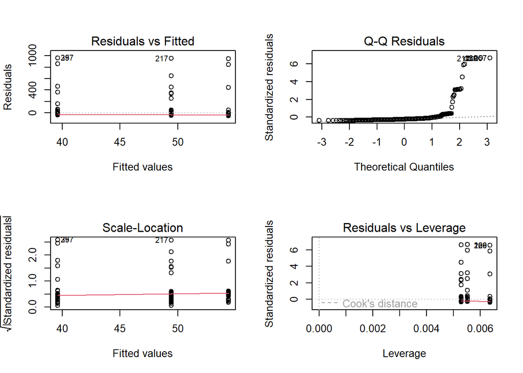

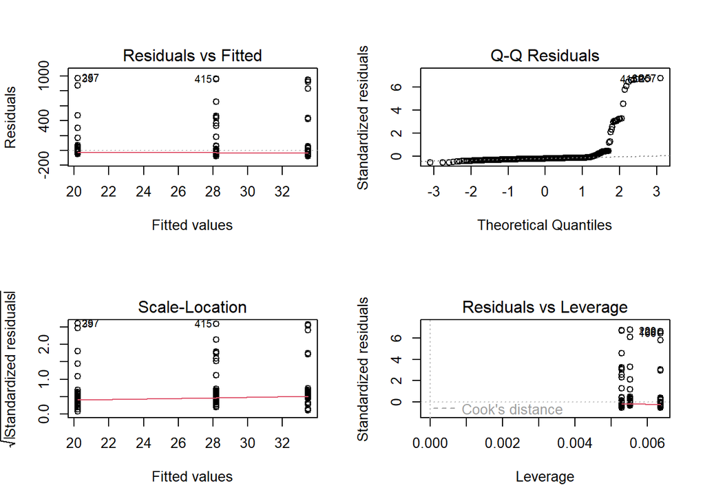

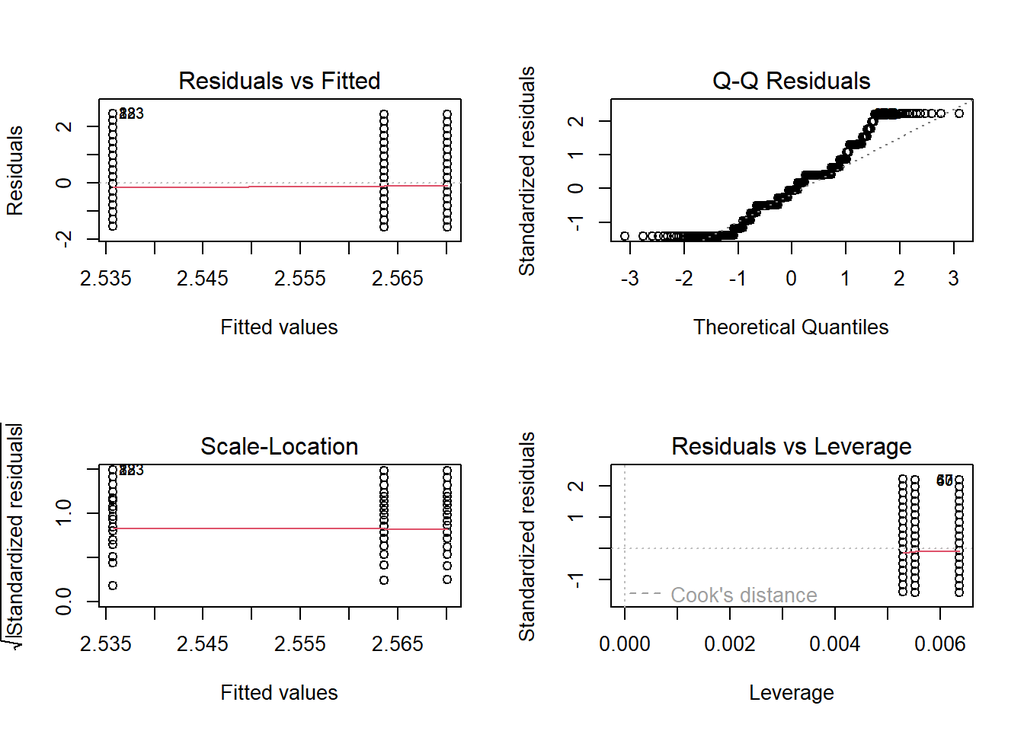

## Chi-square tests for RReject3, Comparative Risk Skepticism

Post hoc test of chi-square test of independece referring to “https://pmc.ncbi.nlm.nih.gov/articles/PMC5737889/”.

In the considered problem for all cells in a contingency table, they are correlated, where the Holm-Bonferroni method can be used.

|  | **Condition** Control | **Condition** Condition a | **Condition** Condition b | **Total** | **p-value** <sup>1</sup> |  |  |
| --- | --- | --- | --- | --- | --- | --- | --- |
| RReject3 |  |  |  |  |  |  | <0.001 |
| higher than | 30 (5.7%) | 35 (6.6%) | 41 (7.8%) | 106 (20%) |  |  |  |
| about the same as | 73 (14%) | 73 (14%) | 108 (20%) | 254 (48%) |  |  |  |
| lower than | 78 (15%) | 49 (9.3%) | 40 (7.6%) | 167 (32%) |  |  |  |
| Total | 181 (34%) | 157 (30%) | 189 (36%) | 527 (100%) |  |  |  |

<sup>1</sup> Pearson’s Chi-squared test

```
    Pearson's Chi-squared test

data:  df$RReject3 and df$Condition
X-squared = 21.336, df = 4, p-value = 0.0002716
```

```
# A tibble: 9 × 5
  RReject3          Condition   Std_residual p_value adjusted_p_value
  <chr>             <chr>              <dbl>   <dbl>            <dbl>
1 higher than       Control           -1.06   0.288            1
2 higher than       Condition a        0.609  0.543            1
3 higher than       Condition b        0.484  0.628            1
4 about the same as Control           -1.52   0.127            0.764
5 about the same as Condition a       -0.307  0.759            1
6 about the same as Condition b        1.77   0.0765           0.536
7 lower than        Control            2.73   0.0064           0.0576
8 lower than        Condition a       -0.106  0.915            1
9 lower than        Condition b       -2.57   0.0102           0.0816
```

| RReject3 | Condition | Std_residual | p_value | adjusted_p_value |
| --- | --- | --- | --- | --- |
| higher than | Control | -1.0617 | 0.2884 | 1.0000 |
| higher than | Condition a | 0.6088 | 0.5427 | 1.0000 |
| higher than | Condition b | 0.4841 | 0.6283 | 1.0000 |
| about the same as | Control | -1.5243 | 0.1274 | 0.7644 |
| about the same as | Condition a | -0.3069 | 0.7589 | 1.0000 |
| about the same as | Condition b | 1.7714 | 0.0765 | 0.5355 |
| lower than | Control | 2.7258 | 0.0064 | 0.0576 |
| lower than | Condition a | -0.1065 | 0.9152 | 1.0000 |
| lower than | Condition b | -2.5703 | 0.0102 | 0.0816 |

|  | **Condition** Control | **Condition** Condition a | **Condition** Condition b | **Total** | **p-value** <sup>1</sup> |  |  |
| --- | --- | --- | --- | --- | --- | --- | --- |
| RReject_comp_2 |  |  |  |  |  |  | 0.6 |
| very underestimate | 24 (4.6%) | 24 (4.6%) | 18 (3.4%) | 66 (13%) |  |  |  |
| underestimate | 76 (14%) | 55 (10%) | 80 (15%) | 211 (40%) |  |  |  |
| accurate estimate | 72 (14%) | 70 (13%) | 81 (15%) | 223 (42%) |  |  |  |
| overestimate | 9 (1.7%) | 8 (1.5%) | 9 (1.7%) | 26 (4.9%) |  |  |  |
| very overestimate | 0 (0%) | 0 (0%) | 1 (0.2%) | 1 (0.2%) |  |  |  |
| Total | 181 (34%) | 157 (30%) | 189 (36%) | 527 (100%) |  |  |  |

<sup>1</sup> Fisher’s exact test

```
    Fisher's Exact Test for Count Data

data:  df$RReject_comp_2 and df$Condition
p-value = 0.6402
alternative hypothesis: two.sided
```

|  | **Condition** Control | **Condition** Condition a | **Condition** Condition b | **Total** | **p-value** <sup>1</sup> |  |  |
| --- | --- | --- | --- | --- | --- | --- | --- |
| RReject_comp_3 |  |  |  |  |  |  | >0.9 |
| underestimate | 100 (19%) | 79 (15%) | 98 (19%) | 277 (53%) |  |  |  |
| accurate estimate | 72 (14%) | 70 (13%) | 81 (15%) | 223 (42%) |  |  |  |
| overestimate | 9 (1.7%) | 8 (1.5%) | 10 (1.9%) | 27 (5.1%) |  |  |  |
| Total | 181 (34%) | 157 (30%) | 189 (36%) | 527 (100%) |  |  |  |

<sup>1</sup> Pearson’s Chi-squared test

```
    Pearson's Chi-squared test

data:  df$RReject_comp_3 and df$Condition
X-squared = 0.91527, df = 4, p-value = 0.9224
```

## Sensitivity analyses to inform outlier decisions

Models with the full data, and set of models that excludes RReject_diff > 90, and a set of models on only those with RReject_diff > 90.

### Excludes RReject_diff > 90 (size = 500)

```
Call:
lm(formula = RReject1 ~ Condition, data = df1)

Residuals:
    Min      1Q  Median      3Q     Max
-20.389 -11.389  -6.094   2.519  81.906

Coefficients:
                     Estimate Std. Error t value Pr(>|t|)
(Intercept)           18.0943     1.5699  11.526   <2e-16 ***
ConditionCondition a   2.2950     2.3150   0.991    0.322
ConditionCondition b   0.4171     2.2170   0.188    0.851
---
Signif. codes:  0 '***' 0.001 '**' 0.01 '*' 0.05 '.' 0.1 ' ' 1

Residual standard error: 20.77 on 497 degrees of freedom
Multiple R-squared:  0.002189,  Adjusted R-squared:  -0.001826
F-statistic: 0.5453 on 2 and 497 DF,  p-value: 0.58
```

```
Call:
lm(formula = RReject_diff ~ Condition, data = df1)

Residuals:
    Min      1Q  Median      3Q     Max
-44.893  -7.199   0.107   2.801  89.231

Coefficients:
                     Estimate Std. Error t value Pr(>|t|)
(Intercept)            -1.231      1.268  -0.971    0.332
ConditionCondition a    1.124      1.870   0.601    0.548
ConditionCondition b   -1.570      1.791  -0.876    0.381

Residual standard error: 16.78 on 497 degrees of freedom
Multiple R-squared:  0.004259,  Adjusted R-squared:  0.0002518
F-statistic: 1.063 on 2 and 497 DF,  p-value: 0.3463
```

```
Call:
lm(formula = RReject_mean ~ Condition, data = df1)

Residuals:
     Min       1Q   Median       3Q      Max
-1.58221 -0.79261 -0.07714  0.45739  2.45739

Coefficients:
                      Estimate Std. Error t value Pr(>|t|)
(Intercept)           2.577143   0.085054  30.300   <2e-16 ***
ConditionCondition a  0.005072   0.125422   0.040    0.968
ConditionCondition b -0.034529   0.120114  -0.287    0.774
---
Signif. codes:  0 '***' 0.001 '**' 0.01 '*' 0.05 '.' 0.1 ' ' 1

Residual standard error: 1.125 on 497 degrees of freedom
Multiple R-squared:  0.0002495, Adjusted R-squared:  -0.003774
F-statistic: 0.06202 on 2 and 497 DF,  p-value: 0.9399
```

```
Linear Regression Results for RReject1, RRejectand RRejects Average (RReject< 90)
================================================================================
                                              Dependent variable:
                               -------------------------------------------------
                                   RReject1       RReject_diff    RReject_mean
                                      (1)             (2)             (3)
--------------------------------------------------------------------------------
ConditionCondition a             2.295 (2.315)   1.124 (1.870)   0.005 (0.125)
ConditionCondition b             0.417 (2.217)   -1.570 (1.791)  -0.035 (0.120)
Constant                       18.094*** (1.570) -1.231 (1.268) 2.577*** (0.085)
--------------------------------------------------------------------------------
Observations                          500             500             500
R2                                   0.002           0.004           0.0002
Adjusted R2                         -0.002           0.0003          -0.004
Residual Std. Error (df = 497)      20.767           16.776          1.125
F Statistic (df = 2; 497)            0.545           1.063           0.062
================================================================================
Note:                                                *p<0.1; **p<0.05; ***p<0.01
```

```
    Pearson's Chi-squared test

data:  df1$RReject3 and df1$Condition
X-squared = 16.153, df = 4, p-value = 0.002821
```

```
    Fisher's Exact Test for Count Data

data:  df1$RReject_comp_2 and df1$Condition
p-value = 0.6288
alternative hypothesis: two.sided
```

|  | **Condition** Control | **Condition** Condition a | **Condition** Condition b | **Total** | **p-value** <sup>1</sup> |  |  |
| --- | --- | --- | --- | --- | --- | --- | --- |
| RReject3 |  |  |  |  |  |  | 0.003 |
| higher than | 29 (5.8%) | 30 (6.0%) | 34 (6.8%) | 93 (19%) |  |  |  |
| about the same as | 72 (14%) | 70 (14%) | 102 (20%) | 244 (49%) |  |  |  |
| lower than | 74 (15%) | 49 (9.8%) | 40 (8.0%) | 163 (33%) |  |  |  |
| Total | 175 (35%) | 149 (30%) | 176 (35%) | 500 (100%) |  |  |  |

<sup>1</sup> Pearson’s Chi-squared test

|  | **Condition** Control | **Condition** Condition a | **Condition** Condition b | **Total** | **p-value** <sup>1</sup> |  |  |
| --- | --- | --- | --- | --- | --- | --- | --- |
| RReject_comp_3 |  |  |  |  |  |  | >0.9 |
| underestimate | 97 (19%) | 77 (15%) | 96 (19%) | 270 (54%) |  |  |  |
| accurate estimate | 69 (14%) | 64 (13%) | 72 (14%) | 205 (41%) |  |  |  |
| overestimate | 9 (1.8%) | 8 (1.6%) | 8 (1.6%) | 25 (5.0%) |  |  |  |
| Total | 175 (35%) | 149 (30%) | 176 (35%) | 500 (100%) |  |  |  |

<sup>1</sup> Pearson’s Chi-squared test

```
    Pearson's Chi-squared test

data:  df1$RReject_comp_3 and df1$Condition
X-squared = 0.58947, df = 4, p-value = 0.9642
```

### Only with RReject_diff >= 90 (size = 27)

```
Call:
lm(formula = RReject1 ~ Condition, data = df1)

Residuals:
    Min      1Q  Median      3Q     Max
-587.50 -187.50   32.15  272.92  532.15

Coefficients:
                     Estimate Std. Error t value Pr(>|t|)
(Intercept)            666.67     130.52   5.108 3.16e-05 ***
ConditionCondition a    20.83     172.66   0.121    0.905
ConditionCondition b  -198.82     157.79  -1.260    0.220
---
Signif. codes:  0 '***' 0.001 '**' 0.01 '*' 0.05 '.' 0.1 ' ' 1

Residual standard error: 319.7 on 24 degrees of freedom
Multiple R-squared:  0.1092,    Adjusted R-squared:  0.035
F-statistic: 1.471 on 2 and 24 DF,  p-value: 0.2496
```

```
Call:
lm(formula = RReject_diff ~ Condition, data = df1)

Residuals:
    Min      1Q  Median      3Q     Max
-568.75 -221.14   18.46  272.96  542.46

Coefficients:
                     Estimate Std. Error t value Pr(>|t|)
(Intercept)            645.33     131.78   4.897  5.4e-05 ***
ConditionCondition a    13.42     174.33   0.077    0.939
ConditionCondition b  -197.79     159.32  -1.242    0.226
---
Signif. codes:  0 '***' 0.001 '**' 0.01 '*' 0.05 '.' 0.1 ' ' 1

Residual standard error: 322.8 on 24 degrees of freedom
Multiple R-squared:  0.1024,    Adjusted R-squared:  0.02756
F-statistic: 1.368 on 2 and 24 DF,  p-value: 0.2737
```

```
Call:
lm(formula = RReject_mean ~ Condition, data = df1)

Residuals:
    Min      1Q  Median      3Q     Max
-1.4423 -0.4423  0.1562  0.5705  1.5577

Coefficients:
                     Estimate Std. Error t value Pr(>|t|)
(Intercept)            2.1667     0.3264   6.637 7.27e-07 ***
ConditionCondition a   0.1771     0.4318   0.410    0.685
ConditionCondition b   0.2756     0.3946   0.698    0.492
---
Signif. codes:  0 '***' 0.001 '**' 0.01 '*' 0.05 '.' 0.1 ' ' 1

Residual standard error: 0.7996 on 24 degrees of freedom
Multiple R-squared:  0.01997,   Adjusted R-squared:  -0.0617
F-statistic: 0.2445 on 2 and 24 DF,  p-value: 0.785
```

[output not shown]

```
    Fisher's Exact Test for Count Data

data:  df1$RReject3 and df1$Condition
p-value = 0.009643
alternative hypothesis: two.sided
```

```
    Fisher's Exact Test for Count Data

data:  df1$RReject_comp_2 and df1$Condition
p-value = 0.48
alternative hypothesis: two.sided
```

|  | **Condition** Control | **Condition** Condition a | **Condition** Condition b | **Total** | **p-value** <sup>1</sup> |  |  |
| --- | --- | --- | --- | --- | --- | --- | --- |
| RReject3 |  |  |  |  |  |  | 0.010 |
| higher than | 1 (3.7%) | 5 (19%) | 7 (26%) | 13 (48%) |  |  |  |
| about the same as | 1 (3.7%) | 3 (11%) | 6 (22%) | 10 (37%) |  |  |  |
| lower than | 4 (15%) | 0 (0%) | 0 (0%) | 4 (15%) |  |  |  |
| Total | 6 (22%) | 8 (30%) | 13 (48%) | 27 (100%) |  |  |  |

<sup>1</sup> Fisher’s exact test

|  | **Condition** Control | **Condition** Condition a | **Condition** Condition b | **Total** | **p-value** <sup>1</sup> |  |  |
| --- | --- | --- | --- | --- | --- | --- | --- |
| RReject_comp_3 |  |  |  |  |  |  | 0.5 |
| underestimate | 3 (11%) | 2 (7.4%) | 2 (7.4%) | 7 (26%) |  |  |  |
| accurate estimate | 3 (11%) | 6 (22%) | 9 (33%) | 18 (67%) |  |  |  |
| overestimate | 0 (0%) | 0 (0%) | 2 (7.4%) | 2 (7.4%) |  |  |  |
| Total | 6 (22%) | 8 (30%) | 13 (48%) | 27 (100%) |  |  |  |

<sup>1</sup> Fisher’s exact test

```
    Fisher's Exact Test for Count Data

data:  df1$RReject_comp_3 and df1$Condition
p-value = 0.48
alternative hypothesis: two.sided
```